# BIOPYTHON

GitHub repository: https://github.com/clarajvv/Phylo-from-Biophyton

Trello: https://trello.com/b/EdWTpv8o/biopython

myBinder: https://mybinder.org/v2/gh/clarajvv/Phylo-from-Biophyton/master

### Introduction

Our objective in this activity is to create phylogenetic trees and to make different queries about them, such as knowing which is the common ancestor, finding out the path from one leaf to another, or simply counting how many terminals are thereñ

To do this, first of all, we will look for examples of proteins that are relevant because of their functions or applications and carry out the study on them. When we have their sequences, we will align them to find out the degree of similarity and, finally, we will create the phylogenetic trees on which we will work.

Using these phylogenetic trees, we'll use some of the functions included in the 'Phylo' section in BioPython to showcase the way they work and their many uses.

### Protein search and reading

On the search for proteins, we considered it appropriate to select two different ones:

```
- Beta casein: it is a major protein component of milk and, in conjunction with the other caseins, it is assembled into micelles. The casein micelles determine many of the physical characteristics of milk, which are important for stability during storage and for milk-processing properties.
- Pyrimidine/purine Nucleoside Phosphorylase: it is a protein that catalyzes the phosphorolysis of diverse nucleosides, yielding D-ribose 1-phosphate and the respective free bases. It can use uridine, adenosine, guanosine, cytidine, thymidine, inosine and xanthosine as substrates. It also catalyzes the reverse reactions.
```

For both cases, we have selected 10 organisms which have that protein. In the case of beta casein, these are organisms such as humans, gorillas and horses, among others; while in the second case, we have selected different species of bacteria.

```python
def read_multiFasta(protein_file):
    fastas = {}

    file = open(protein_file)

    for line in file:

        if (line[0]==">"):
            head=line[1:]
            seq=""

        else:
            line=line.rstrip("\r")
            seq+=line.rstrip("\n")
            fastas[head]=seq

    return fastas
```

```python
read_multiFasta("BetaCasein.txt")
```

```
{'sp|P05814|CASB_HUMAN Beta-casein OS=Homo sapiens OX=9606 GN=CSN2 PE=1 SV=4\n': 'MKVLILACLVALALARETIESLSSSEESITEYKQKVEKVKHEDQQQGEDEHQDKIYPSFQ…',
 'tr|G3RZH2|G3RZH2_GORGO Beta-casein OS=Gorilla gorilla gorilla OX=9595 PE=3 SV=1\n': 'MKVLILACLVALALARETVESLSSSEESITEYKQKVEKVKHEDQQQGEDEHQDKIYHSFQ…',
 'tr|H2QPK9|H2QPK9_PANTR Beta-casein OS=Pan troglodytes OX=9598 GN=CSN2 PE=3 SV=1\n': 'MKVLILACLVALALARETVESLSSSEESITEYKQKVEKVKHEDQQQGEDEHQDKIYPSFQ…',
 'tr|A0A2R8Z5M4|A0A2R8Z5M4_PANPA Beta-casein OS=Pan paniscus OX=9597 GN=CSN2 PE=3 SV=1\n': 'MKVLILACLVALALARETVESLSSSEESITEYKQKVEKVKHEDQQQGEDEHQDKIYPSFQ…',
 'tr|G1R7Y4|G1R7Y4_NOMLE Beta-casein OS=Nomascus leucogenys OX=61853 GN=CSN2 PE=3 SV=2\n': 'MKVLILACLVALALARETVESLSSSEETITQYKQEVEKVKHEDQQQGEDEHQDKIYPSFQ…',
 'tr|H2PDH0|H2PDH0_PONAB Beta-casein OS=Pongo abelii OX=9601 GN=CSN2 PE=3 SV=1\n': 'MKVLILACLVALAFARETVESLSSSEETITQYEQKVEKVKHEDQQQGEDEHQNKIYPSFQ…',
 'tr|A0A0D9QY03|A0A0D9QY03_CHLSB Beta-casein OS=Chlorocebus sabaeus OX=60711 GN=CSN2 PE=3 SV=1\n': 'MKVIILACLVALALARETVENLSSSEESITQYKQTVEKVKHEDQQQREDERQDKIDPSFQ…',
 'tr|A0A2K5U2F4|A0A2K5U2F4_MACFA Beta-casein OS=Macaca fascicularis OX=9541 GN=CSN2 PE=3 SV=1\n': 'MKVIILACLVALALARETVENLSSSEESITQYKQTVEKVKHEDQQQREDERQDKIDPSFQ…',
 'sp|Q9GKK3|CASB_HORSE Beta-casein OS=Equus caballus OX=9796 GN=CSN2 PE=1 SV=3\n': 'MKILILACLVALALAREKEELNVSSETVESLSSNEPDSSSEESITHINKEKLQKFKHEGQ…',
 'sp|Q9TSI0|CASB_BUBBU Beta-casein OS=Bubalus bubalis OX=89462 GN=CSN2 PE=2 SV=1\n': 'MKVLILACLVALALARELEELNVPGEIVESLSSSEESITHINKKIEKFQSEEQQQMEDEL…'}
```

```python
read_multiFasta("PyrimidinePurineNucleosidePhosphorylase.txt")
```

```
{'sp|P0C037|PPNP_ECOLI Pyrimidine/purine nucleoside phosphorylase OS=Escherichia coli (strain K12) OX=83333 GN=ppnP PE=1 SV=1\n': 'MLQSNEYFSGKVKSIGFSSSSTGRASVGVMVEGEYTFSTAEPEEMTVISGALNVLLPDATDWQVYEAGSVFNVPGHSEFHLQVAEPTSYLCRYL',
 'sp|Q9KKY0|PPNP_VIBCH Pyrimidine/purine nucleoside phosphorylase OS=Vibrio cholerae serotype O1 (strain ATCC 39315 / El Tor Inaba N16961) OX=243277 GN=ppnP PE=3 SV=2\n': 'MIKENVYFDGNVKSLGFSQQDGESTVGVMAPGQYTFGTGAPERMTVVKGALTIKRVTDADWVTFTAGEAFEVAGNSSFDLQVEVATAYLCEFLPA',
 'sp|Q8XWC2|PPNP_RALSO Pyrimidine/purine nucleoside phosphorylase OS=Ralstonia solanacearum (strain GMI1000) OX=267608 GN=ppnP PE=3 SV=2\n': 'MTTETIDGVRLTTKANVYFDGKCVSHSFALPDGTKKSVGVVLPATLTFGTAAAEIMECVGGSCEYRLDGSDEWKQSGPGERFQVPANSKFDIRVTEAYHYICHYA',
 'sp|A0KK62|PPNP_AERHH Pyrimidine/purine nucleoside phosphorylase OS=Aeromonas hydrophila subsp. hydrophila (strain ATCC 7966 / DSM 30187 / JCM 1027 / KCTC 2358 / NCIMB 9240) OX=380703 GN=ppnP PE=3 SV=2\n': 'MLKVNEYFDGNVKSIGFEQKGDKATVGVMEAGHYQFNTAAPERMTVVKGALTIQLADEDEWHTYEQGQSFDVAGHSSFKLEVKTPTAYLCEF…
 'sp|Q2SC73|PPNP_HAHCH Pyrimidine/purine nucleoside phosphorylase OS=Hahella chejuensis (strain KCTC 2396) OX=349521 GN=ppnP PE=3 SV=2\n': 'MLKVNEYFNGRVKSIAFQTATLPATVGVMIPGDYEFSTSQHETMTVVSGALSVKLPESESWTRFNAGDRFEIPANATFNLKVAVDTAYLCTYG',
 'sp|Q9I3E3|PPNP_PSEAE Pyrimidine/purine nucleoside phosphorylase OS=Pseudomonas aeruginosa (strain ATCC 15692 / DSM 22644 / CIP 104116 / JCM 14847 / LMG 12228 / 1C / PRS 101 / PAO1) OX=208964 GN=ppnP PE=3 SV=1\n': 'MFKVNEYFDGTVKSIAFDMTAGPATIGVMAAGEYEFGTSQLEIMHVVAGALTVKLPGSDEWQEYASGSQFTVPANSKFQLKVAQ…
 'sp|A8AK73|PPNP_CITK8 Pyrimidine/purine nucleoside phosphorylase OS=Citrobacter koseri (strain ATCC BAA-895 / CDC 4225-83 / SGSC4696) OX=290338 GN=ppnP PE=3 SV=2\n': 'MLQSNEYFSGKVKSIGFTSSSTGRASVGVMAEGEYAFSTAAPEEMTVVSGALNVLLPGETEWKVYAAGEVFNVPGQSEFHLQVAEPTSYLCRYL',
 'sp|Q6LLX8|PPNP_PHOPR Pyrimidine/purine nucleoside phosphorylase OS=Photobacterium profundum (strain SS9) OX=298386 GN=ppnP PE=3 SV=2\n': 'MLNVNEYFEGQVKSIGFEAQGDRTSVGVMAAGEYTFGTAAPERMTVVKGSMDVKRPGHVEWETFNAGDDFEVPGDSSFEVKITSSTAYLCDYL',
 'sp|Q0K784|PPNP_CUPNH Pyrimidine/purine nucleoside phosphorylase OS=Cupriavidus necator (strain ATCC 17699 / H16 / DSM 428 / Stanier 337) OX=381666 GN=ppnP PE=3 SV=2\n': 'MEVSQFDNVSVVKKANLYFDGKCVSHTVLFPDGTRKTLGVIFPAALTFNTGAPEIMEINAGTCRVRLAGSEDWQTYGAGQQFSVPGNSSFDIEVQETLDYVCHFA',
 'sp|Q8E927|PPNP_SHEON Pyrimidine/purine nucleoside phosphorylase OS=Shewanella oneidensis (strain MR-1) OX=211586 GN=ppnP PE=3 SV=1\n': 'MELIEQVAVAKKANIYFEGKVASRSVFFSDGSKQTLGVVLPGEYEFSTSQGEIMHVTSGSFEVLLPNSSTWQAFSEGSQFELAANVSFKIRNNAIAEYCCRYL'}
```

### ClustalW2

In order to create the phylogenetic trees, we are going to use ClustalW2. ClustalW2 is the command-line interface of Clustal, a computer program for performing multiple sequence alignments and creating phylogenetic trees.

In our project, we will implement *clustal_wrapper*, a class which will use biopython functions of Alingment tools section, and whose purpose is to be an adapter for ClustalW2.

#### Download and install of ClustalW2

First, we will show the steps for downloading ClustalW2:

1. Enter in Clustal W official website in: ["http://www.clustal.org/clustal2/">](http://www.clustal.org/clustal2/)

Then download clustalw suited for your computer.

[figure not shown]

1. Use the setup file to install ClustalW2. Pay attention to the installation location.

[figure not shown]

1. Now, we will train the ClustarW2 application with 'opuntia.fasta', a fasta file with some DNA sequences.

[figure not shown]

#### Adapter class

##### Implementation

We want to use ClustalW2 from our python project to create phylogenetic trees. For this purpose, we use biopython functions in the class ClusterWrapper.

When we initialize *clustal_wrapper*, the only input parameter is the path where the file clustal.exe is. The function asks for it because we use it, with *os* package functions, instead of modifying the path. Then, the class has the function *generate_aligment_tree*, which needs the fasta file with the sequence and uses ClustalW2 to create the alignment and the phylogenetic tree. Subsequently, we will use this tree to show some of the functions included in the 'Phylo' section in BioPython.

```python
import os
from Bio.Align.Applications import ClustalwCommandline


class ClustalWrapper:
    def __init__(self, clustal_exe_path):
        self.clustalw_exe = clustal_exe_path

    def generate_alignment_tree(self, fasta_file):
        try:
            clustalw_cline = ClustalwCommandline(self.clustalw_exe, infile=fasta_file, seqnos="ON")
            assert os.path.isfile(self.clustalw_exe), "Clustal W executable missing"
            stdout, stderr = clustalw_cline()
        except:
            raise Exception("ClustalW2 did not work")
```

##### Unit test

Although our class does not create the files itself, it makes use of ClustalW2 for generating the phylogenetic trees. Therefore, we have to check if the phylogenetic tree's file (file with dnd extension) is correct.

Python has a package, **filecmp**, that allows us to compare two files using its function *cmp* and returning a boolean value which indicates if the two files are equals.

```python
import unittest
from phylo.clustal_wrapper import ClustalWrapper
import filecmp

class TestClustalWrapper(unittest.TestCase):

    def test_dndfile(self):
        clustalWPath = "D:\clustalForBiopython\CLustalW2.exe"
        clustalWrapper = ClustalWrapper(clustalWPath)
        clustalWrapper.generate_alignment_tree('..\\phylo\\proteins\\opuntia.fasta')
        isEqual = filecmp.cmp('..\\phylo\\test\\testFiles\\correctOpuntia.dnd', '..\\phylo\\proteins\\opuntia.dnd', shallow= False)
        self.assertTrue(isEqual)

if __name__ == '__main__':
    unittest.main()
```

### Phylo

Finally, we use the Biopython functions intended to create and work with phylogenetic trees. There are a lot of them, and they allow us to work with the trees and understand them better.

#### Reading

First of all, we need to save our trees into variables. To do so, we call the *read* function from Phylo. Our trees are the ones stored in *BetaCasein.dnd* and *PyrimidinePurineNucleosidePhosphorylase.dnd*, in the *files* folder. Since these files have been created using ClustalW2, their formar is *newick*.

```python
from Bio import Phylo
import sys
from io import StringIO
treeBC = Phylo.read("files/BetaCasein.dnd", "newick")
treePPN = Phylo.read("files/PyrimidinePurineNucleosidePhosphorylase.dnd", "newick")
```

#### Printing

Now, let's say we want to print our tree. Well, we have four different options. We can print it using the clade format, we can print it drawing branches, we can create a new window with an image of it, or we can write in in xml format. We've created a function to make it easier to do this, with the different options ranging from 1 to 4.

```python
def drawTree(tree, type):
    if type == 1:
        print(tree)
    elif type == 2:
        Phylo.draw_ascii(tree)
    elif type == 3:
        tree.rooted = True
        Phylo.draw(tree)
    elif type == 4:
        Phylo.write(tree, sys.stdout, "phyloxml")
```

Here we see how each one of these outputs work:

```python
drawTree(treeBC, 1)
```

```
Tree(rooted=False, weight=1.0)
    Clade()
        Clade(branch_length=0.00861, name='sp|P05814|CASB_HUMAN')
        Clade(branch_length=0.00106)
            Clade(branch_length=0.01215, name='tr|G3RZH2|G3RZH2_GORGO')
            Clade(branch_length=0.01412)
                Clade(branch_length=0.00697)
                    Clade(branch_length=0.01779, name='tr|G1R7Y4|G1R7Y4_NOMLE')
                    Clade(branch_length=0.03973, name='tr|H2PDH0|H2PDH0_PONAB')
                Clade(branch_length=0.02017)
                    Clade(branch_length=0.03122)
                        Clade(branch_length=0.00189, name='tr|A0A0D9QY03|A0A0D9QY03_CHLSB')
                        Clade(branch_length=0.00696, name='tr|A0A2K5U2F4|A0A2K5U2F4_MACFA')
                    Clade(branch_length=0.20363)
                        Clade(branch_length=0.16524, name='sp|Q9GKK3|CASB_HORSE')
                        Clade(branch_length=0.21869, name='sp|Q9TSI0|CASB_BUBBU')
        Clade(branch_length=0.00028)
            Clade(branch_length=0.00444, name='tr|H2QPK9|H2QPK9_PANTR')
            Clade(branch_length=0.01333, name='tr|A0A2R8Z5M4|A0A2R8Z5M4_PANPA')
```

```python
drawTree(treeBC, 2)
```

```
 , sp|P05814|CASB_HUMAN
 , tr|G3RZH2|G3RZH2_GORGO
 | , tr|G1R7Y4|G1R7Y4_NOMLE
 |,|
 |||___ tr|H2PDH0|H2PDH0_PONAB
 ||
_||    , tr|A0A0D9QY03|A0A0D9QY03_CHLSB
 ||  __|
 || |  | tr|A0A2K5U2F4|A0A2K5U2F4_MACFA
 ||_|
 |  |                    _______________ sp|Q9GKK3|CASB_HORSE
 |  |___________________|
 |                      |_____________________ sp|Q9TSI0|CASB_BUBBU
 , tr|H2QPK9|H2QPK9_PANTR
 | tr|A0A2R8Z5M4|A0A2R8Z5M4_PANPA
```

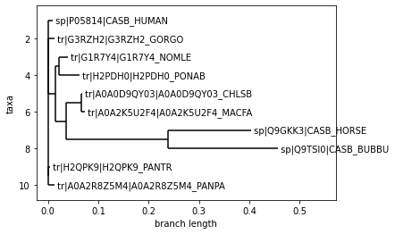

```python
drawTree(treeBC, 3)
```

```python
drawTree(treeBC, 4)
```

```
<phyloxml xmlns:xsi="http://www.w3.org/2001/XMLSchema-instance" xmlns="http://www.phyloxml.org" xsi:schemaLocation="http://www.phyloxml.org http://www.phyloxml.org/1.10/phyloxml.xsd">
  <phylogeny rooted="false">
    <clade>
      <clade>
        <name>sp|P05814|CASB_HUMAN</name>
        <branch_length>0.00861</branch_length>
      </clade>
      <clade>
        <branch_length>0.00106</branch_length>
        <clade>
          <name>tr|G3RZH2|G3RZH2_GORGO</name>
          <branch_length>0.01215</branch_length>
        </clade>
        <clade>
          <branch_length>0.01412</branch_length>
          <clade>
            <branch_length>0.00697</branch_length>
            <clade>
              <name>tr|G1R7Y4|G1R7Y4_NOMLE</name>
              <branch_length>0.01779</branch_length>
            </clade>
            <clade>
              <name>tr|H2PDH0|H2PDH0_PONAB</name>
              <branch_length>0.03973</branch_length>
            </clade>
          </clade>
          <clade>
            <branch_length>0.02017</branch_length>
            <clade>
              <branch_length>0.03122</branch_length>
              <clade>
                <name>tr|A0A0D9QY03|A0A0D9QY03_CHLSB</name>
                <branch_length>0.00189</branch_length>
              </clade>
              <clade>
                <name>tr|A0A2K5U2F4|A0A2K5U2F4_MACFA</name>
                <branch_length>0.00696</branch_length>
              </clade>
            </clade>
            <clade>
```

[output cut: 12 more lines]

```
      </clade>
      <clade>
        <branch_length>0.00028</branch_length>
        <clade>
          <name>tr|H2QPK9|H2QPK9_PANTR</name>
          <branch_length>0.00444</branch_length>
        </clade>
        <clade>
          <name>tr|A0A2R8Z5M4|A0A2R8Z5M4_PANPA</name>
          <branch_length>0.01333</branch_length>
        </clade>
      </clade>
    </clade>
  </phylogeny>
</phyloxml>
```

```python
drawTree(treePPN, 1)
```

```
Tree(rooted=False, weight=1.0)
    Clade()
        Clade(branch_length=0.01932)
            Clade(branch_length=0.16295)
                Clade(branch_length=0.07253, name='sp|P0C037|PPNP_ECOLI')
                Clade(branch_length=0.05513, name='sp|A8AK73|PPNP_CITK8')
            Clade(branch_length=0.02921)
                Clade(branch_length=0.0682)
                    Clade(branch_length=0.07734)
                        Clade(branch_length=0.23181, name='sp|Q8XWC2|PPNP_RALSO')
                        Clade(branch_length=0.23486, name='sp|Q0K784|PPNP_CUPNH')
                    Clade(branch_length=0.29612, name='sp|Q8E927|PPNP_SHEON')
                Clade(branch_length=0.03701)
                    Clade(branch_length=0.20753, name='sp|Q2SC73|PPNP_HAHCH')
                    Clade(branch_length=0.17957, name='sp|Q9I3E3|PPNP_PSEAE')
        Clade(branch_length=0.02779)
            Clade(branch_length=0.20648, name='sp|Q9KKY0|PPNP_VIBCH')
            Clade(branch_length=0.18714, name='sp|A0KK62|PPNP_AERHH')
        Clade(branch_length=0.21089, name='sp|Q6LLX8|PPNP_PHOPR')
```

```python
drawTree(treePPN, 2)
```

```
                         ________ sp|P0C037|PPNP_ECOLI
    ____________________|
   |                    |______ sp|A8AK73|PPNP_CITK8
  _|                      _____________________________ sp|Q8XWC2|PPNP_RALSO
 | |            _________|
 | |    _______|         |______________________________ sp|Q0K784|PPNP_CUPNH
 | |   |       |
 | |___|       |_____________________________________ sp|Q8E927|PPNP_SHEON
 |     |
 |     |    __________________________ sp|Q2SC73|PPNP_HAHCH
_|     |___|
 |         |______________________ sp|Q9I3E3|PPNP_PSEAE
 |   __________________________ sp|Q9KKY0|PPNP_VIBCH
 |__|
 |  |_______________________ sp|A0KK62|PPNP_AERHH
 |__________________________ sp|Q6LLX8|PPNP_PHOPR
```

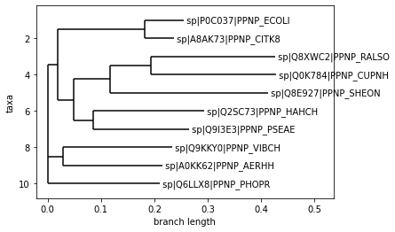

```python
drawTree(treePPN, 3)
```

```python
drawTree(treePPN, 4)
```

```
<phyloxml xmlns:xsi="http://www.w3.org/2001/XMLSchema-instance" xmlns="http://www.phyloxml.org" xsi:schemaLocation="http://www.phyloxml.org http://www.phyloxml.org/1.10/phyloxml.xsd">
  <phylogeny rooted="true">
    <clade>
      <clade>
        <branch_length>0.01932</branch_length>
        <clade>
          <branch_length>0.16295</branch_length>
          <clade>
            <name>sp|P0C037|PPNP_ECOLI</name>
            <branch_length>0.07253</branch_length>
          </clade>
          <clade>
            <name>sp|A8AK73|PPNP_CITK8</name>
            <branch_length>0.05513</branch_length>
          </clade>
        </clade>
        <clade>
          <branch_length>0.02921</branch_length>
          <clade>
            <branch_length>0.0682</branch_length>
            <clade>
              <branch_length>0.07734</branch_length>
              <clade>
                <name>sp|Q8XWC2|PPNP_RALSO</name>
                <branch_length>0.23181</branch_length>
              </clade>
              <clade>
                <name>sp|Q0K784|PPNP_CUPNH</name>
                <branch_length>0.23486</branch_length>
              </clade>
            </clade>
            <clade>
              <name>sp|Q8E927|PPNP_SHEON</name>
              <branch_length>0.29612</branch_length>
            </clade>
          </clade>
          <clade>
            <branch_length>0.03701</branch_length>
            <clade>
              <name>sp|Q2SC73|PPNP_HAHCH</name>
```

[output cut: 12 more lines]

```
          <name>sp|Q9KKY0|PPNP_VIBCH</name>
          <branch_length>0.20648</branch_length>
        </clade>
        <clade>
          <name>sp|A0KK62|PPNP_AERHH</name>
          <branch_length>0.18714</branch_length>
        </clade>
      </clade>
      <clade>
        <name>sp|Q6LLX8|PPNP_PHOPR</name>
        <branch_length>0.21089</branch_length>
      </clade>
    </clade>
  </phylogeny>
</phyloxml>
```

Trees can also be partially printed. We can create them from scratch, using a string:

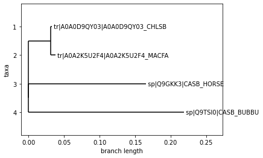

```python
fragment = StringIO(
    "((tr|A0A0D9QY03|A0A0D9QY03_CHLSB:0.00189,tr|A0A2K5U2F4|A0A2K5U2F4_MACFA:0.00696):0.03122,(sp|Q9GKK3|CASB_HORSE:0.16524,sp|Q9TSI0|CASB_BUBBU:0.21869));")
partialTree = Phylo.read(fragment, "newick")
drawTree(partialTree, 3)
```

Or, knowing a tree, we can navigate its clades (or branches)

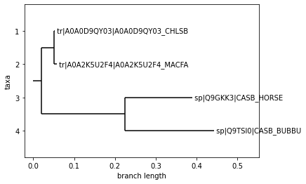

```python
drawTree(treeBC.clade[1,1,1], 3)
```

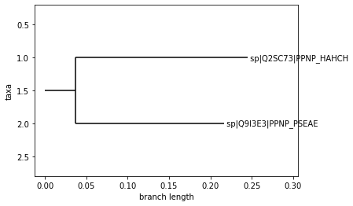

```python
drawTree(treePPN.clade[0,1,1], 3)
```

#### Terminals

Another function that can help us have a gereral view of our tree is getting its terminals and non terminals.

```python
def terminales(tree):
    return tree.get_terminals(), tree.get_nonterminals()
```

```python
terminales(treeBC)
```

```
([Clade(branch_length=0.00861, name='sp|P05814|CASB_HUMAN'),
  Clade(branch_length=0.01215, name='tr|G3RZH2|G3RZH2_GORGO'),
  Clade(branch_length=0.01779, name='tr|G1R7Y4|G1R7Y4_NOMLE'),
  Clade(branch_length=0.03973, name='tr|H2PDH0|H2PDH0_PONAB'),
  Clade(branch_length=0.00189, name='tr|A0A0D9QY03|A0A0D9QY03_CHLSB'),
  Clade(branch_length=0.00696, name='tr|A0A2K5U2F4|A0A2K5U2F4_MACFA'),
  Clade(branch_length=0.16524, name='sp|Q9GKK3|CASB_HORSE'),
  Clade(branch_length=0.21869, name='sp|Q9TSI0|CASB_BUBBU'),
  Clade(branch_length=0.00444, name='tr|H2QPK9|H2QPK9_PANTR'),
  Clade(branch_length=0.01333, name='tr|A0A2R8Z5M4|A0A2R8Z5M4_PANPA')],
 [Clade(),
  Clade(branch_length=0.00106),
  Clade(branch_length=0.01412),
  Clade(branch_length=0.00697),
  Clade(branch_length=0.02017),
  Clade(branch_length=0.03122),
  Clade(branch_length=0.20363),
  Clade(branch_length=0.00028)])
```

```python
terminales(treePPN)
```

```
([Clade(branch_length=0.07253, name='sp|P0C037|PPNP_ECOLI'),
  Clade(branch_length=0.05513, name='sp|A8AK73|PPNP_CITK8'),
  Clade(branch_length=0.23181, name='sp|Q8XWC2|PPNP_RALSO'),
  Clade(branch_length=0.23486, name='sp|Q0K784|PPNP_CUPNH'),
  Clade(branch_length=0.29612, name='sp|Q8E927|PPNP_SHEON'),
  Clade(branch_length=0.20753, name='sp|Q2SC73|PPNP_HAHCH'),
  Clade(branch_length=0.17957, name='sp|Q9I3E3|PPNP_PSEAE', rooted=True),
  Clade(branch_length=0.20648, name='sp|Q9KKY0|PPNP_VIBCH'),
  Clade(branch_length=0.18714, name='sp|A0KK62|PPNP_AERHH'),
  Clade(branch_length=0.21089, name='sp|Q6LLX8|PPNP_PHOPR')],
 [Clade(),
  Clade(branch_length=0.01932),
  Clade(branch_length=0.16295),
  Clade(branch_length=0.02921),
  Clade(branch_length=0.0682),
  Clade(branch_length=0.07734),
  Clade(branch_length=0.03701, rooted=True),
  Clade(branch_length=0.02779)])
```

#### More functions

In this section we'll explain a series of functions that can help us navigate and work with the trees in much more depth.

**Common ancestors**

One of the principal objectives of phylogenetic trees is to get to know the common ancestors between two species. Biopython's function to do so is *common_ancestor*. To be executed, it needs to know the name of the branches you are trying to connect. These names must be given like dictionaries, with the format *{"name":"branchName"}*. But once we try it with our files, we discover a problem.

Our tree has species with compound names, which have three parts and are separated by a |. This causes a problem with the method, since the common ancestor it returns isnt the real one. Here we have an example:

```python
drawTree(treePPN, 1)
```

```
Tree(rooted=True, weight=1.0)
    Clade()
        Clade(branch_length=0.01932)
            Clade(branch_length=0.16295)
                Clade(branch_length=0.07253, name='sp|P0C037|PPNP_ECOLI')
                Clade(branch_length=0.05513, name='sp|A8AK73|PPNP_CITK8')
            Clade(branch_length=0.02921)
                Clade(branch_length=0.0682)
                    Clade(branch_length=0.07734)
                        Clade(branch_length=0.23181, name='sp|Q8XWC2|PPNP_RALSO')
                        Clade(branch_length=0.23486, name='sp|Q0K784|PPNP_CUPNH')
                    Clade(branch_length=0.29612, name='sp|Q8E927|PPNP_SHEON')
                Clade(branch_length=0.03701, rooted=True)
                    Clade(branch_length=0.20753, name='sp|Q2SC73|PPNP_HAHCH')
                    Clade(branch_length=0.17957, name='sp|Q9I3E3|PPNP_PSEAE', rooted=True)
        Clade(branch_length=0.02779)
            Clade(branch_length=0.20648, name='sp|Q9KKY0|PPNP_VIBCH')
            Clade(branch_length=0.18714, name='sp|A0KK62|PPNP_AERHH')
        Clade(branch_length=0.21089, name='sp|Q6LLX8|PPNP_PHOPR')
```

Looking at this tree, we can see the common ancestor between *sp|Q9KKY0|PPNP_VIBCH* and *sp|A0KK62|PPNP_AERHH* is a clade with branch_lenght=0.02779. But if we try to use the *common_ancestor* method, we get the wrong answer:

```python
treePPN.common_ancestor({"name": "sp|Q9KKY0|PPNP_VIBCH"},{"name":"sp|A0KK62|PPNP_AERHH"})
```

```
Clade(branch_length=0.07253, name='sp|P0C037|PPNP_ECOLI')
```

After a series of tests, we have discovered that the method only works when we have simpler names, so we have created alternative *dnd* files where we have changed each species' name, removing the first two words and sticking with the third one, which is always different. These files are *BCSimp.dnd* and *PPNsimpl.dnd*.

So let's try using them:

```python
smpBC=Phylo.read("files/BCsimpl.dnd", "newick")
smpPPN=Phylo.read("files/PPNsimpl.dnd", "newick")
```

Now, we should get the correct results.

```python
smpBC.common_ancestor({"name":"A0A0D9QY03_CHLSB"}, {"name":"CASB_HORSE"})
```

```
Clade(branch_length=0.02017)
```

```python
smpPPN.common_ancestor({"name":"PPNP_RALSO"}, {"name":"PPNP_CUPNH"})
```

```
Clade(branch_length=0.07734)
```

These answers are indeed correct, as we can see if we draw the trees with the first drawing option. Since we have found this problem, from now on we'll use those new files with reduced names to avoid having more issues.

Now we have that sorted, we can explore the importance of the *common_ancestor* method. Maybe when we execute it and get an answer it isnt really clear, but there's something we can do to get a better perspective. We can color the path from this common ancestor to its heirs. This is very useful when we want to track the results of a mutation or a certain moment in evolution. There are two ways to do this:

First, if we don't know the exact location of the common ancestor we are looking for, we first use the common_ancestor function to get it, then we change the color of its ramifications, and lastly, we draw it.

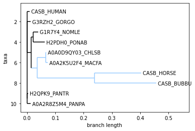

```python
comunBC=smpBC.common_ancestor({"name":"A0A0D9QY03_CHLSB"}, {"name":"CASB_HORSE"})
comunBC.color="#99ccff"
drawTree(smpBC, 3)
```

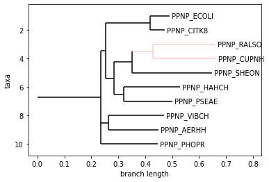

```python
comunPPN=smpPPN.common_ancestor({"name":"PPNP_RALSO"}, {"name":"PPNP_CUPNH"})
comunPPN.color="#ffcccc"
drawTree(smpPPN, 3)
```

This second way doesn't require using the *common_ancestor* function, but it can only be done when you know the exact location of it beforehand. Therefore, it way may not be realistic when we have a bigger phylogenetic tree.

To represent the exact same common ancestors from before, we'd need to do the following (we have to first reload the files because the variables we have are already colored):

```python
smpBC=Phylo.read("files/BCsimpl.dnd", "newick")
smpPPN=Phylo.read("files/PPNsimpl.dnd", "newick")
```

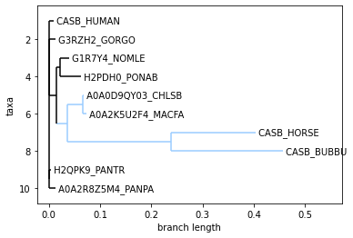

```python
smpBC.clade[1,1,1].color="#99ccff"
drawTree(smpBC,3)
```

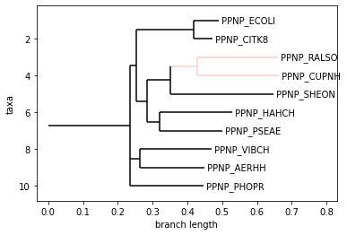

```python
smpPPN.clade[0,1,0,0].color="#ffcccc"
drawTree(smpPPN,3)
```

**Path**

Another relevant function is *path*, which displays the path betweeen the root of the tree and the chosen clade. It makes it easier to follow the track a protein has gone through during its evolution.

```python
smpBC.get_path(name="G1R7Y4_NOMLE")
```

```
[Clade(branch_length=0.00106),
 Clade(branch_length=0.01412),
 Clade(branch_length=0.00697),
 Clade(branch_length=0.01779, name='G1R7Y4_NOMLE')]
```

```python
smpPPN.get_path(name="PPNP_SHEON")
```

```
[Clade(branch_length=0.01932),
 Clade(branch_length=0.02921),
 Clade(branch_length=0.0682),
 Clade(branch_length=0.29612, name='PPNP_SHEON')]
```

**Trace**

Trace is similar to *path*. It returns the path between two given leafs in the tree.

**Distance**

This one returns the distance between two leafs, and therefore it makes a lot of sense to use it with *trace*.

```python
print("BC\nTrace: " + str(smpBC.trace("CASB_HORSE", "H2QPK9_PANTR")) +
"\nDistance: "+str(smpBC.distance("CASB_HORSE", "H2QPK9_PANTR")))
```

```
BC
Trace: [Clade(branch_length=0.20363), Clade(branch_length=0.02017), Clade(branch_length=0.01412), Clade(branch_length=0.00106), Clade(), Clade(branch_length=0.00028), Clade(branch_length=0.00444, name='H2QPK9_PANTR')]
Distance: 0.40894
```

```python
print("PPN\nTrace: " + str(smpPPN.trace("PPNP_CUPNH", "PPNP_AERHH")) +
"\nDistance: "+str(smpPPN.distance("PPNP_CUPNH", "PPNP_AERHH")))
```

```
PPN
Trace: [Clade(branch_length=0.07734), Clade(branch_length=0.0682), Clade(branch_length=0.02921), Clade(branch_length=0.01932), Clade(branch_length=0.235), Clade(branch_length=0.02779), Clade(branch_length=0.18714, name='PPNP_AERHH')]
Distance: 0.6438600000000001
```

**Count Terminals**

This is a really simple function, and it does just as it says, it counts the terminals a tree has.

**Branch Length**

This second one returns the total branche length of the tree. Again, it makes sense to join these two methods.

```python
print("BC\nTerminals: " +str(smpPPN.count_terminals()) + "\nTotal branch length: "+ str(smpBC.total_branch_length())+ "\n\nPPN\nTerminals: " + str(smpBC.count_terminals()) +"\nTotal branch length: "+ str(smpPPN.total_branch_length()))
```

```
BC
Terminals: 10
Total branch length: 0.7662799999999999

PPN
Terminals: 10
Total branch length: 2.53888
```

The following methods modify my tree, so it's best to first create a copy in order not to overwrite it.

```python
import copy
copPNN=copy.deepcopy(smpPPN)
```

**Collapse**

We begin with *collapse*, a method that, given an element from the tree, deletes it. If this element has any branches, they'll be connected to the elements' parent.

A variant of this method is *collapse_all*, which brings every leaf to the same level, deleting all ramifications

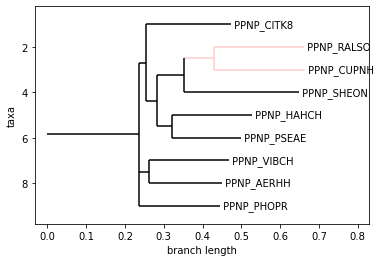

```python
copPNN.collapse("PPNP_ECOLI")
drawTree(copPNN,3)
```

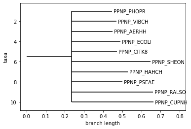

```python
copPNN=copy.deepcopy(smpPPN)
copPNN.collapse_all()
drawTree(copPNN,3)
```

**Ladderize**

This method can organize a tree, showing the shallower branches first and the deeper ones last.

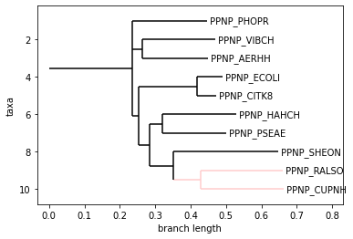

```python
copPNN=copy.deepcopy(smpPPN)
copPNN.ladderize()
drawTree(copPNN,3)
```

### Final thoughts

By creating this report we have further proved that bioinformatics are essential to biology, specially in fields related to genetics. The Phylo module in this Biopython package is really useful, providing a series of methods that can make the process of creating, navigating, consulting and modifiying a phylogenetic tree much easier.

It allows us to represent it in a really intuitive way, and the commands throughout which we can work with it are easy to use and remember. It includes a complete set of functions that, in our opinion, make a researcher's work easier, even if they aren't familiar with programming languages.